# Import Library

```python
import os
import sys
import numpy as np
import warnings
warnings.simplefilter(action='ignore', category=FutureWarning)

import pandas as pd
from pandas.plotting import scatter_matrix
import matplotlib as mpl
import matplotlib.pyplot as plt

from jupyterthemes import jtplot
jtplot.style(theme='monokai', context='notebook', ticks=True, grid=True)

plt.rcParams["font.family"] = "Malgun Gothic"
plt.rcParams["figure.figsize"] = (12,5)
plt.rcParams['axes.unicode_minus'] = False
```

# Read Data

```python
header_list = ["CRIM", "ZN", "INDUS", "CHAS", "NOX", "RM", "AGE", \
         "DIS", "RAD", "TAX", "PTRATIO", "B", "LSTAT", "MEDV"]
housing_df = pd.read_csv("housing.data", header=None, delim_whitespace=True, names=header_list)
housing_df
```

|  | CRIM | ZN | INDUS | CHAS | NOX | RM | AGE | DIS | RAD | TAX | PTRATIO | B | LSTAT | MEDV |
| --- | --- | --- | --- | --- | --- | --- | --- | --- | --- | --- | --- | --- | --- | --- |
| 0 | 0.00632 | 18.0 | 2.31 | 0 | 0.538 | 6.575 | 65.2 | 4.0900 | 1 | 296.0 | 15.3 | 396.90 | 4.98 | 24.0 |
| 1 | 0.02731 | 0.0 | 7.07 | 0 | 0.469 | 6.421 | 78.9 | 4.9671 | 2 | 242.0 | 17.8 | 396.90 | 9.14 | 21.6 |
| 2 | 0.02729 | 0.0 | 7.07 | 0 | 0.469 | 7.185 | 61.1 | 4.9671 | 2 | 242.0 | 17.8 | 392.83 | 4.03 | 34.7 |
| 3 | 0.03237 | 0.0 | 2.18 | 0 | 0.458 | 6.998 | 45.8 | 6.0622 | 3 | 222.0 | 18.7 | 394.63 | 2.94 | 33.4 |
| 4 | 0.06905 | 0.0 | 2.18 | 0 | 0.458 | 7.147 | 54.2 | 6.0622 | 3 | 222.0 | 18.7 | 396.90 | 5.33 | 36.2 |
| ... | ... | ... | ... | ... | ... | ... | ... | ... | ... | ... | ... | ... | ... | ... |
| 501 | 0.06263 | 0.0 | 11.93 | 0 | 0.573 | 6.593 | 69.1 | 2.4786 | 1 | 273.0 | 21.0 | 391.99 | 9.67 | 22.4 |
| 502 | 0.04527 | 0.0 | 11.93 | 0 | 0.573 | 6.120 | 76.7 | 2.2875 | 1 | 273.0 | 21.0 | 396.90 | 9.08 | 20.6 |
| 503 | 0.06076 | 0.0 | 11.93 | 0 | 0.573 | 6.976 | 91.0 | 2.1675 | 1 | 273.0 | 21.0 | 396.90 | 5.64 | 23.9 |
| 504 | 0.10959 | 0.0 | 11.93 | 0 | 0.573 | 6.794 | 89.3 | 2.3889 | 1 | 273.0 | 21.0 | 393.45 | 6.48 | 22.0 |
| 505 | 0.04741 | 0.0 | 11.93 | 0 | 0.573 | 6.030 | 80.8 | 2.5050 | 1 | 273.0 | 21.0 | 396.90 | 7.88 | 11.9 |

506 rows × 14 columns

# Variable description

| 번호 | 설명 | 설명 | 타입 | 타입 |
| --- | --- | --- | --- | --- |
| 1 | CRIM per capita crime rate by town | 범죄율(%) | float | continuous |
| 2 | ZN proportion of residential land zoned for lots over25,000 sq.ft. | 주거용지비율(%) | float | continuous |
| 3 | INDUS proportion of non-retail business acres per town | 비소매업비율(%) | float | continuous |
| 4 | CHAS Charles River dummy variable (= 1 if tract bounds river; 0 otherwise) | 강인접여부 | category | binary |
| 5 | NOX nitric oxides concentration (parts per 10 million) | 산화질소농도 | float | continuous |
| 6 | RM average number of rooms per dwelling | 평균방수 | float | continuous |
| 7 | AGE proportion of owner-occupied units built prior to 1940 | 노후주택비율(%) | float | continuous |
| 8 | DIS weighted distances to five Boston employment centres | 일자리거리 | float | continuous |
| 9 | RAD index of accessibility to radial highways | 도로접근지수 | int | continuous |
| 10 | TAX full-value property-tax rate per \$10,000 | 재산세 | int | continuous |
| 11 | PTRATIO pupil-teacher ratio by town | 학생교사비율 | float | continuous |
| 12 | B 1000(Bk - 0.63)^2 where Bk is the proportion of blacks by town | 흑인비율지수 | float | continuous |
| 13 | LSTAT \% lower status of the population | 저소득자비율(\%) | flaot | continuous |
| 14 | MEDV Median value of owner-occupied homes in \$1000's | 주택중앙값 | float | continuous |

# 데이터 탐색

```python
# check NaN and type
housing_df.info()
```

```
<class 'pandas.core.frame.DataFrame'>
RangeIndex: 506 entries, 0 to 505
Data columns (total 14 columns):
 #   Column   Non-Null Count  Dtype
---  ------   --------------  -----
 0   CRIM     506 non-null    float64
 1   ZN       506 non-null    float64
 2   INDUS    506 non-null    float64
 3   CHAS     506 non-null    int64
 4   NOX      506 non-null    float64
 5   RM       506 non-null    float64
 6   AGE      506 non-null    float64
 7   DIS      506 non-null    float64
 8   RAD      506 non-null    int64
 9   TAX      506 non-null    float64
 10  PTRATIO  506 non-null    float64
 11  B        506 non-null    float64
 12  LSTAT    506 non-null    float64
 13  MEDV     506 non-null    float64
dtypes: float64(12), int64(2)
memory usage: 55.5 KB
```

```python
# type casting
dtype_dic = {"CHAS": "category", "TAX": "int64"}
housing_df = housing_df.astype(dtype_dic)
housing_df.dtypes
```

```
CRIM        float64
ZN          float64
INDUS       float64
CHAS       category
NOX         float64
RM          float64
AGE         float64
DIS         float64
RAD           int64
TAX           int64
PTRATIO     float64
B           float64
LSTAT       float64
MEDV        float64
dtype: object
```

### Multivariate Outlier filtering

[XGBoost with outlier filtering]  
Training Accuracy: 98.88264877386924  
Testing Accuracy: 89.27153356322862  
R Squre: 97.03003572611946  
Mean Absolute Error: 0.10931981510858571  
[XGBoost without outlier filtering]  
Training Accuracy: 99.12971851823485  
Testing Accuracy: 71.6654882939101  
R Squre: 93.78986471708915  
Mean Absolute Error: 0.11612814698880419  
IQR, z-score 같은 Univariate outlier filtering 보다 multivariate outlier filtering 방법이 효과적

```python
# multivariate outlier detection techniques. Cook's distance
import statsmodels.api as sm

# exclude binary variables
housing_df_woB = housing_df.drop(columns=['CHAS'])

X = housing_df_woB.drop(columns=['MEDV'])
y = housing_df_woB['MEDV']

# add a constant to fit the intercept
X['CONSTANT'] = 1

model = sm.OLS(y, X).fit()
ols_inf = model.get_influence()
Di = ols_inf.summary_frame().cooks_d

print (Di.sort_values(ascending=False)[:10])
```

```
368    0.168757
365    0.067968
412    0.053976
372    0.051232
367    0.047483
214    0.046130
371    0.042760
369    0.038941
414    0.038450
364    0.036851
Name: cooks_d, dtype: float64
```

```python
housing_df_o = housing_df_woB[Di < 0.01]
housing_df_o['CHAS'] = housing_df['CHAS'][housing_df_o.index]
housing_df_o
```

|  | CRIM | ZN | INDUS | NOX | RM | AGE | DIS | RAD | TAX | PTRATIO | B | LSTAT | MEDV | CHAS |
| --- | --- | --- | --- | --- | --- | --- | --- | --- | --- | --- | --- | --- | --- | --- |
| 0 | 0.00632 | 18.0 | 2.31 | 0.538 | 6.575 | 65.2 | 4.0900 | 1 | 296 | 15.3 | 396.90 | 4.98 | 24.0 | 0 |
| 1 | 0.02731 | 0.0 | 7.07 | 0.469 | 6.421 | 78.9 | 4.9671 | 2 | 242 | 17.8 | 396.90 | 9.14 | 21.6 | 0 |
| 2 | 0.02729 | 0.0 | 7.07 | 0.469 | 7.185 | 61.1 | 4.9671 | 2 | 242 | 17.8 | 392.83 | 4.03 | 34.7 | 0 |
| 3 | 0.03237 | 0.0 | 2.18 | 0.458 | 6.998 | 45.8 | 6.0622 | 3 | 222 | 18.7 | 394.63 | 2.94 | 33.4 | 0 |
| 4 | 0.06905 | 0.0 | 2.18 | 0.458 | 7.147 | 54.2 | 6.0622 | 3 | 222 | 18.7 | 396.90 | 5.33 | 36.2 | 0 |
| ... | ... | ... | ... | ... | ... | ... | ... | ... | ... | ... | ... | ... | ... | ... |
| 501 | 0.06263 | 0.0 | 11.93 | 0.573 | 6.593 | 69.1 | 2.4786 | 1 | 273 | 21.0 | 391.99 | 9.67 | 22.4 | 0 |
| 502 | 0.04527 | 0.0 | 11.93 | 0.573 | 6.120 | 76.7 | 2.2875 | 1 | 273 | 21.0 | 396.90 | 9.08 | 20.6 | 0 |
| 503 | 0.06076 | 0.0 | 11.93 | 0.573 | 6.976 | 91.0 | 2.1675 | 1 | 273 | 21.0 | 396.90 | 5.64 | 23.9 | 0 |
| 504 | 0.10959 | 0.0 | 11.93 | 0.573 | 6.794 | 89.3 | 2.3889 | 1 | 273 | 21.0 | 393.45 | 6.48 | 22.0 | 0 |
| 505 | 0.04741 | 0.0 | 11.93 | 0.573 | 6.030 | 80.8 | 2.5050 | 1 | 273 | 21.0 | 396.90 | 7.88 | 11.9 | 0 |

482 rows × 14 columns

### Normalization

[XGBoost with StandardScaler]  
Training Accuracy: 98.88264877386924  
Testing Accuracy: 89.27153356322862  
R Squre: 97.03003572611946  
Mean Absolute Error: 0.10931981510858571  
[XGBoost with MinMaxScaler]  
Training Accuracy: 98.8585407296331  
Testing Accuracy: 88.93666093557621  
R Squre: 96.94600774428368  
Mean Absolute Error: 0.02016943502695454  
[XGBoost without normalization]  
Training Accuracy: 98.75234922883624  
Testing Accuracy: 88.77121310147092  
R Squre: 96.82854104928632  
Mean Absolute Error: 0.9502218135659626  
큰 차이는 없음 StandardScaler 사용

```python
from sklearn.preprocessing import StandardScaler
from sklearn.preprocessing import MinMaxScaler

scaler = StandardScaler()
# scaler = MinMaxScaler()
fitted = scaler.fit(housing_df_o)
# print(fitted.mean_)

output = scaler.transform(housing_df_o)
housing_df_o_n = pd.DataFrame(output, columns=housing_df_o.columns, index=list(housing_df_o.index.values))
housing_df_o_n
```

|  | CRIM | ZN | INDUS | NOX | RM | AGE | DIS | RAD | TAX | PTRATIO | B | LSTAT | MEDV | CHAS |
| --- | --- | --- | --- | --- | --- | --- | --- | --- | --- | --- | --- | --- | --- | --- |
| 0 | -0.434958 | 0.259193 | -1.262380 | -0.120405 | 0.476886 | -0.098156 | 0.110076 | -0.967141 | -0.644621 | -1.457818 | 0.434794 | -1.135971 | 0.256751 | -0.253017 |
| 1 | -0.432181 | -0.499113 | -0.564830 | -0.715895 | 0.229621 | 0.392243 | 0.531417 | -0.850600 | -0.968387 | -0.300515 | 0.434794 | -0.519347 | -0.035466 | -0.253017 |
| 2 | -0.432184 | -0.499113 | -0.564830 | -0.715895 | 1.456315 | -0.244917 | 0.531417 | -0.850600 | -0.968387 | -0.300515 | 0.389911 | -1.276786 | 1.559551 | -0.253017 |
| 3 | -0.431512 | -0.499113 | -1.281431 | -0.810828 | 1.156064 | -0.792589 | 1.057481 | -0.734060 | -1.088300 | 0.116114 | 0.409761 | -1.438353 | 1.401267 | -0.253017 |
| 4 | -0.426659 | -0.499113 | -1.281431 | -0.810828 | 1.395302 | -0.491906 | 1.057481 | -0.734060 | -1.088300 | 0.116114 | 0.434794 | -1.084091 | 1.742186 | -0.253017 |
| ... | ... | ... | ... | ... | ... | ... | ... | ... | ... | ... | ... | ... | ... | ... |
| 501 | -0.427509 | -0.499113 | 0.147374 | 0.181655 | 0.505787 | 0.041447 | -0.664008 | -0.967141 | -0.782521 | 1.180833 | 0.380648 | -0.440787 | 0.061939 | -0.253017 |
| 502 | -0.429805 | -0.499113 | 0.147374 | 0.181655 | -0.253672 | 0.313493 | -0.755809 | -0.967141 | -0.782521 | 1.180833 | 0.434794 | -0.528241 | -0.157223 | -0.253017 |
| 503 | -0.427756 | -0.499113 | 0.147374 | 0.181655 | 1.120741 | 0.825369 | -0.813455 | -0.967141 | -0.782521 | 1.180833 | 0.434794 | -1.038141 | 0.244575 | -0.253017 |
| 504 | -0.421297 | -0.499113 | 0.147374 | 0.181655 | 0.828517 | 0.764517 | -0.707099 | -0.967141 | -0.782521 | 1.180833 | 0.396748 | -0.913631 | 0.013237 | -0.253017 |
| 505 | -0.429522 | -0.499113 | 0.147374 | 0.181655 | -0.398177 | 0.460255 | -0.651326 | -0.967141 | -0.782521 | 1.180833 | 0.434794 | -0.706113 | -1.216509 | -0.253017 |

482 rows × 14 columns

```python
# summary statistics
housing_df_o_n.describe()
```

|  | CRIM | ZN | INDUS | NOX | RM | AGE | DIS | RAD | TAX | PTRATIO | B | LSTAT | MEDV | CHAS |
| --- | --- | --- | --- | --- | --- | --- | --- | --- | --- | --- | --- | --- | --- | --- |
| count | 4.820000e+02 | 4.820000e+02 | 4.820000e+02 | 4.820000e+02 | 4.820000e+02 | 4.820000e+02 | 4.820000e+02 | 4.820000e+02 | 4.820000e+02 | 4.820000e+02 | 4.820000e+02 | 4.820000e+02 | 4.820000e+02 | 4.820000e+02 |
| mean | 8.844930e-17 | 8.660661e-17 | 5.896620e-17 | -2.063817e-16 | -1.363593e-16 | 3.537972e-16 | 5.896620e-17 | -1.768986e-16 | 5.896620e-17 | 1.179324e-16 | 7.370775e-17 | -7.370775e-17 | -5.896620e-17 | -1.105616e-17 |
| std | 1.001039e+00 | 1.001039e+00 | 1.001039e+00 | 1.001039e+00 | 1.001039e+00 | 1.001039e+00 | 1.001039e+00 | 1.001039e+00 | 1.001039e+00 | 1.001039e+00 | 1.001039e+00 | 1.001039e+00 | 1.001039e+00 | 1.001039e+00 |
| min | -4.349576e-01 | -4.991130e-01 | -1.533487e+00 | -1.440839e+00 | -3.436014e+00 | -2.328217e+00 | -1.290616e+00 | -9.671408e-01 | -1.298148e+00 | -2.707705e+00 | -3.938554e+00 | -1.580651e+00 | -2.056633e+00 | -2.530171e-01 |
| 25% | -4.252679e-01 | -4.991130e-01 | -8.491259e-01 | -8.971312e-01 | -6.237673e-01 | -8.758134e-01 | -8.292472e-01 | -6.175194e-01 | -7.555407e-01 | -5.204022e-01 | 2.109598e-01 | -8.024605e-01 | -6.198999e-01 | -2.530171e-01 |
| 50% | -4.057886e-01 | -4.991130e-01 | -3.464796e-01 | -1.721868e-01 | -1.276303e-01 | 3.063340e-01 | -2.576070e-01 | -5.009789e-01 | -4.437662e-01 | 2.549908e-01 | 3.794348e-01 | -1.710144e-01 | -1.085204e-01 | -2.530171e-01 |
| 75% | -2.522812e-02 | 3.223848e-01 | 1.051551e+00 | 6.217999e-01 | 5.045832e-01 | 9.175427e-01 | 6.631374e-01 | -1.513575e-01 | 1.573775e+00 | 8.104963e-01 | 4.278462e-01 | 6.353394e-01 | 3.511124e-01 | -2.530171e-01 |
| max | 9.291488e+00 | 3.713696e+00 | 2.464237e+00 | 2.753482e+00 | 3.895255e+00 | 1.147529e+00 | 3.970650e+00 | 1.713290e+00 | 1.843579e+00 | 1.643755e+00 | 4.347936e-01 | 3.279705e+00 | 3.422433e+00 | 3.952302e+00 |

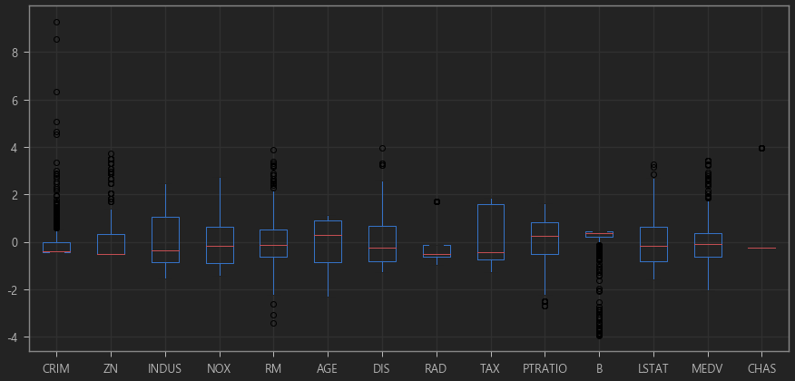

```python
housing_df_o_n.boxplot(figsize=(15, 7))
```

[output not shown]

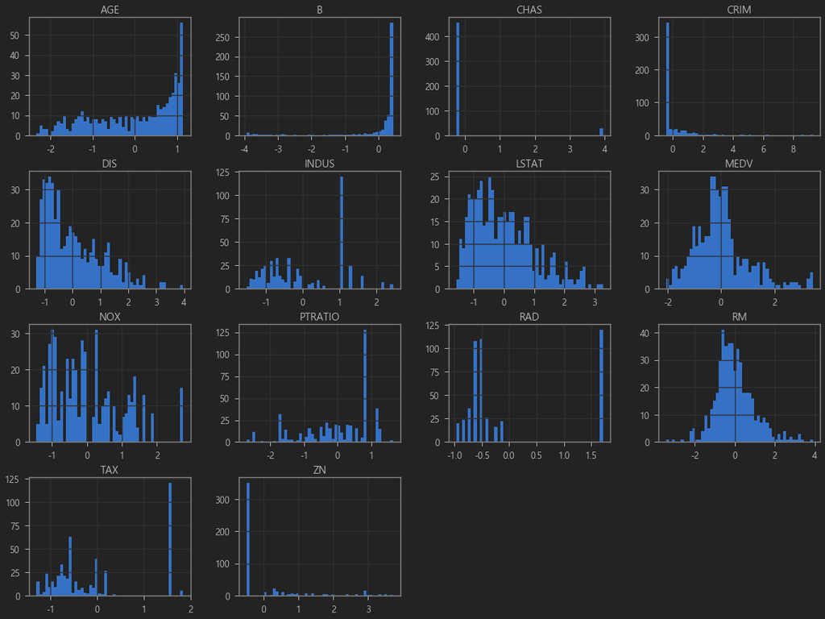

```python
# histogram
housing_df_o_n.hist(bins=50, figsize=(20, 15))
```

```python
# non-normal dist correlation - spearman
corr = housing_df_o_n.corr(method ='spearman') #'pearson','kendall','spearman'
corr.style.background_gradient(cmap='coolwarm').set_precision(2)
```

|  | CRIM | ZN | INDUS | NOX | RM | AGE | DIS | RAD | TAX | PTRATIO | B | LSTAT | MEDV | CHAS |
| --- | --- | --- | --- | --- | --- | --- | --- | --- | --- | --- | --- | --- | --- | --- |
| CRIM | 1.00 | -0.57 | 0.73 | 0.82 | -0.32 | 0.70 | -0.73 | 0.71 | 0.71 | 0.47 | -0.35 | 0.68 | -0.61 | 0.01 |
| ZN | -0.57 | 1.00 | -0.65 | -0.64 | 0.38 | -0.55 | 0.61 | -0.27 | -0.36 | -0.46 | 0.15 | -0.52 | 0.48 | -0.02 |
| INDUS | 0.73 | -0.65 | 1.00 | 0.79 | -0.44 | 0.67 | -0.75 | 0.45 | 0.65 | 0.46 | -0.27 | 0.69 | -0.64 | 0.05 |
| NOX | 0.82 | -0.64 | 0.79 | 1.00 | -0.32 | 0.80 | -0.88 | 0.57 | 0.63 | 0.40 | -0.28 | 0.68 | -0.61 | 0.03 |
| RM | -0.32 | 0.38 | -0.44 | -0.32 | 1.00 | -0.28 | 0.26 | -0.10 | -0.27 | -0.30 | 0.04 | -0.63 | 0.64 | 0.01 |
| AGE | 0.70 | -0.55 | 0.67 | 0.80 | -0.28 | 1.00 | -0.80 | 0.41 | 0.50 | 0.36 | -0.22 | 0.71 | -0.60 | 0.04 |
| DIS | -0.73 | 0.61 | -0.75 | -0.88 | 0.26 | -0.80 | 1.00 | -0.48 | -0.55 | -0.32 | 0.23 | -0.62 | 0.51 | -0.03 |
| RAD | 0.71 | -0.27 | 0.45 | 0.57 | -0.10 | 0.41 | -0.48 | 1.00 | 0.69 | 0.31 | -0.27 | 0.43 | -0.39 | -0.01 |
| TAX | 0.71 | -0.36 | 0.65 | 0.63 | -0.27 | 0.50 | -0.55 | 0.69 | 1.00 | 0.45 | -0.32 | 0.58 | -0.61 | -0.10 |
| PTRATIO | 0.47 | -0.46 | 0.46 | 0.40 | -0.30 | 0.36 | -0.32 | 0.31 | 0.45 | 1.00 | -0.08 | 0.48 | -0.58 | -0.16 |
| B | -0.35 | 0.15 | -0.27 | -0.28 | 0.04 | -0.22 | 0.23 | -0.27 | -0.32 | -0.08 | 1.00 | -0.24 | 0.22 | -0.02 |
| LSTAT | 0.68 | -0.52 | 0.69 | 0.68 | -0.63 | 0.71 | -0.62 | 0.43 | 0.58 | 0.48 | -0.24 | 1.00 | -0.85 | 0.01 |
| MEDV | -0.61 | 0.48 | -0.64 | -0.61 | 0.64 | -0.60 | 0.51 | -0.39 | -0.61 | -0.58 | 0.22 | -0.85 | 1.00 | 0.09 |
| CHAS | 0.01 | -0.02 | 0.05 | 0.03 | 0.01 | 0.04 | -0.03 | -0.01 | -0.10 | -0.16 | -0.02 | 0.01 | 0.09 | 1.00 |

[output not shown]

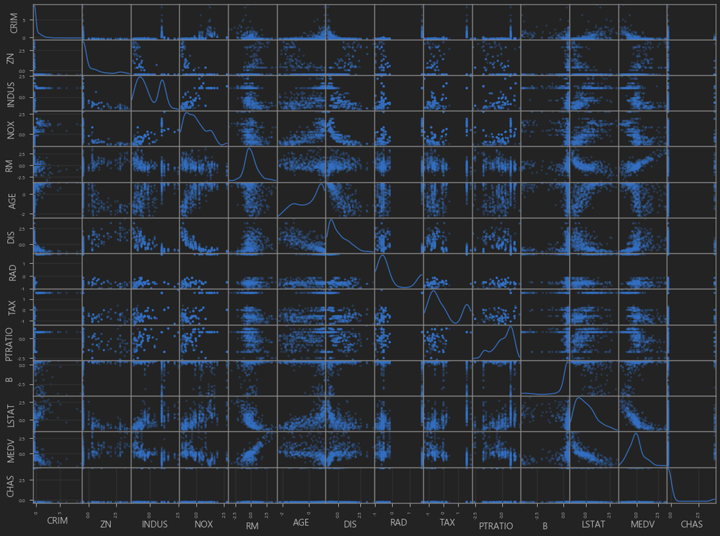

```python
scatter_matrix(housing_df_o_n, diagonal='kde', color='b', alpha=0.3, figsize=(20, 15))
```

# Feature 선정

1. Tree-based feature selection  
   ExtraTreesClassifier와 같은 트리 기반 모델은 Feature Importance 를 제공  
   Feature Importance는 불확실도를 많이 낮출수록 증가하므로 이를 기준으로 변수 선택
2. RFE (recursive feature elimination)  
   반복해서 학습을 진행하면서 중요도가 낮은 변수를 하나씩 제거하는 방식

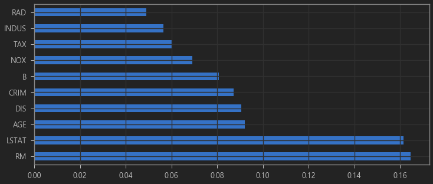

```
['RM', 'LSTAT', 'AGE', 'DIS', 'CRIM', 'B', 'NOX', 'TAX', 'INDUS', 'RAD']
```

```python
# Tree-based feature selection
from sklearn.ensemble import ExtraTreesClassifier
import matplotlib.pyplot as plt

X = housing_df_o_n.drop(columns=["MEDV"]) #.iloc[:,0:13] #independent columns
y = housing_df_o_n['MEDV'] #target column 'MEDV'
y = np.round(housing_df_o_n['MEDV'])

model = ExtraTreesClassifier()
model.fit(X,y)

# print(model.feature_importances_) #use inbuilt class feature_importances of tree based classifiers

# Plot graph of feature importances for better visualization
feat_importances = pd.Series(model.feature_importances_, index=X.columns)
feat_importances.nlargest(10).plot(kind='barh')
plt.show()

tree_target_features = feat_importances.nlargest(10).index.to_list()
tree_target_features
```

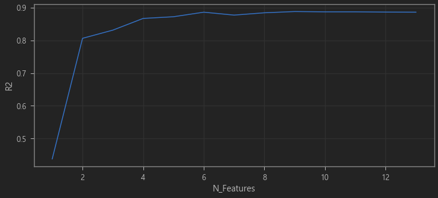

```
['CRIM', 'NOX', 'RM', 'TAX', 'PTRATIO', 'LSTAT']
```

```python
# RFE recursive feature elimination
from sklearn.model_selection import train_test_split
from sklearn.ensemble import RandomForestRegressor
from sklearn.metrics import mean_squared_error, r2_score
from sklearn.feature_selection import RFE

X = housing_df_o_n.drop(columns=["MEDV"])
y = housing_df_o_n["MEDV"] #target column

X_train, X_test, y_train, y_test = train_test_split(X,y,test_size=0.20,random_state=0)

model = RandomForestRegressor()

r2_list = []
for i in range(1, X.shape[1]+1):
    rfe = RFE(model, n_features_to_select=i)
    fit = rfe.fit(X_train, y_train)

    # predict prices of X_test
    y_pred = fit.predict(X_test)
    r2 = r2_score(y_test, y_pred)
    r2_list.append(r2)

plt.plot(range(1, X.shape[1]+1), r2_list)
plt.xlabel("N_Features")
plt.ylabel("R2")
plt.show()

# R2 saturated n_features
rfe = RFE(model, n_features_to_select=6)
fit = rfe.fit(X_train, y_train)

rfe_target_features = X.columns[fit.support_].to_list()
rfe_target_features
```

# 예측 모형 학습 및 Evaluation

# 1. Random Forest Regressor

DNN 을 사용하기에는 sample size 가 작다.  
Ensemble 방식이 Linear regression 에 비해 정확도가 더 높음  
Random Forest 는 Ensemble bagging 방식으로 Parameter tuning 이 거의없음

```python
from sklearn.model_selection import train_test_split
from sklearn.ensemble import RandomForestRegressor
from sklearn.metrics import mean_absolute_error, r2_score

# feat_importances
X = housing_df_o_n[rfe_target_features]
# X = housing_df_o_n.drop(columns=["MEDV"])
y = housing_df_o_n["MEDV"] #target column

X_train, X_test, y_train, y_test = train_test_split(X,y,test_size=0.20,random_state=0)

model = RandomForestRegressor()
model.fit(X_train, y_train)

y_pred = model.predict(X_train)
print("Training Accuracy:", model.score(X_train, y_train)*100)
print("Testing Accuracy:", model.score(X_test, y_test)*100)
print("R Squre:", r2_score(y, model.predict(X))*100)
print("Mean Absolute Error:", mean_absolute_error(model.predict(X), y))
```

```
Training Accuracy: 98.45509067540802
Testing Accuracy: 88.79820305673547
R Squre: 96.59427927871407
Mean Absolute Error: 0.12197376578370349
```

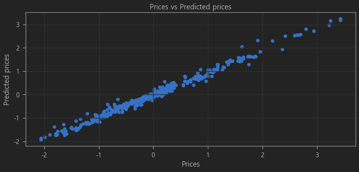

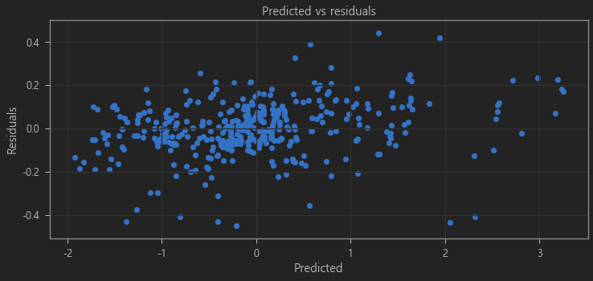

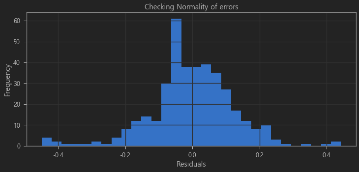

```python
plt.scatter(y_train, y_pred)
plt.xlabel("Prices")
plt.ylabel("Predicted prices")
plt.title("Prices vs Predicted prices")
plt.show()

#check residuals
plt.scatter(y_pred, y_train-y_pred)
plt.xlabel("Predicted")
plt.ylabel("Residuals")
plt.title("Predicted vs residuals")
plt.show()

# Checking Normality of errors
(y_train-y_pred).plot.hist(bins=30)
plt.xlabel("Residuals")
plt.title("Checking Normality of errors")
plt.show()
```

### Random Forest Regressor Cross-validation

```python
from sklearn.model_selection import train_test_split
from sklearn.ensemble import RandomForestRegressor
from sklearn.metrics import mean_squared_error, r2_score
from sklearn.model_selection import cross_val_score
from sklearn.model_selection import KFold
from sklearn.model_selection import GridSearchCV

# data
X = housing_df_o_n.drop(columns=["MEDV"])
y = housing_df_o_n["MEDV"] #target column

X_train, X_test, y_train, y_test = train_test_split(X,y,test_size=0.20,random_state=0)

# specify regression model
model = RandomForestRegressor()
model.fit(X_train, y_train)

# cross-validation scheme
folds = KFold(n_splits = 5, shuffle = True, random_state = 100)

# hyperparameters range
hyper_params = [{'n_features_to_select': list(range(1, 13))}]

# perform grid search
model = RandomForestRegressor()
model.fit(X_train, y_train)
rfe = RFE(model)

# call GridSearchCV()
model_cv = GridSearchCV(estimator = rfe,
                        param_grid = hyper_params,
                        scoring= 'r2',
                        cv = folds,
                        verbose = 1,
                        return_train_score=True)

# fit the model
model_cv.fit(X_train, y_train)

# cv results
cv_results = pd.DataFrame(model_cv.cv_results_)
cv_results
```

```
Fitting 5 folds for each of 12 candidates, totalling 60 fits
```

```
[Parallel(n_jobs=1)]: Using backend SequentialBackend with 1 concurrent workers.
[Parallel(n_jobs=1)]: Done  60 out of  60 | elapsed:  1.3min finished
```

|  | mean_fit_time | std_fit_time | mean_score_time | std_score_time | param_n_features_to_select | params | split0_test_score | split1_test_score | split2_test_score | split3_test_score | ... | mean_test_score | std_test_score | rank_test_score | split0_train_score | split1_train_score | split2_train_score | split3_train_score | split4_train_score | mean_train_score | std_train_score |
| --- | --- | --- | --- | --- | --- | --- | --- | --- | --- | --- | --- | --- | --- | --- | --- | --- | --- | --- | --- | --- | --- |
| 0 | 2.027387 | 0.009211 | 0.006383 | 0.000488 | 1 | {'n_features_to_select': 1} | 0.670117 | 0.167221 | 0.431168 | 0.566732 | ... | 0.454478 | 0.168796 | 12 | 0.916169 | 0.920362 | 0.925906 | 0.912847 | 0.903337 | 0.915724 | 0.007578 |
| 1 | 1.930446 | 0.016233 | 0.006578 | 0.000795 | 2 | {'n_features_to_select': 2} | 0.886622 | 0.672463 | 0.738480 | 0.837114 | ... | 0.774532 | 0.076856 | 11 | 0.966741 | 0.974828 | 0.972882 | 0.970801 | 0.976726 | 0.972395 | 0.003447 |
| 2 | 1.820922 | 0.030482 | 0.006389 | 0.000496 | 3 | {'n_features_to_select': 3} | 0.900834 | 0.710128 | 0.806752 | 0.878393 | ... | 0.819944 | 0.067022 | 10 | 0.974491 | 0.979891 | 0.979055 | 0.976676 | 0.978537 | 0.977730 | 0.001933 |
| 3 | 1.676902 | 0.040860 | 0.006383 | 0.000489 | 4 | {'n_features_to_select': 4} | 0.903596 | 0.738958 | 0.840250 | 0.894561 | ... | 0.841623 | 0.058827 | 9 | 0.977803 | 0.982194 | 0.980312 | 0.980331 | 0.980969 | 0.980322 | 0.001433 |
| 4 | 1.500984 | 0.008898 | 0.006588 | 0.000493 | 5 | {'n_features_to_select': 5} | 0.907753 | 0.741298 | 0.873214 | 0.890999 | ... | 0.852430 | 0.058895 | 8 | 0.980522 | 0.982279 | 0.980426 | 0.980898 | 0.983128 | 0.981451 | 0.001070 |
| 5 | 1.398728 | 0.011454 | 0.006588 | 0.000482 | 6 | {'n_features_to_select': 6} | 0.911360 | 0.759842 | 0.886681 | 0.892631 | ... | 0.860315 | 0.053899 | 7 | 0.980252 | 0.983406 | 0.981754 | 0.980858 | 0.982057 | 0.981665 | 0.001081 |
| 6 | 1.236309 | 0.013867 | 0.006192 | 0.000396 | 7 | {'n_features_to_select': 7} | 0.909442 | 0.771644 | 0.886846 | 0.903743 | ... | 0.866223 | 0.050383 | 6 | 0.980264 | 0.983882 | 0.981730 | 0.983251 | 0.983367 | 0.982499 | 0.001328 |
| 7 | 1.069531 | 0.007200 | 0.006179 | 0.000387 | 8 | {'n_features_to_select': 8} | 0.911170 | 0.784378 | 0.882139 | 0.894075 | ... | 0.868375 | 0.044136 | 5 | 0.980976 | 0.985425 | 0.980021 | 0.981284 | 0.983749 | 0.982291 | 0.001992 |
| 8 | 0.904569 | 0.009225 | 0.006585 | 0.000482 | 9 | {'n_features_to_select': 9} | 0.915495 | 0.775059 | 0.888376 | 0.898383 | ... | 0.869675 | 0.049452 | 4 | 0.983262 | 0.983819 | 0.982870 | 0.982957 | 0.983202 | 0.983222 | 0.000333 |
| 9 | 0.727455 | 0.006929 | 0.006776 | 0.000396 | 10 | {'n_features_to_select': 10} | 0.908932 | 0.782419 | 0.896369 | 0.905465 | ... | 0.872253 | 0.047154 | 3 | 0.983159 | 0.984742 | 0.982307 | 0.983873 | 0.982887 | 0.983394 | 0.000842 |
| 10 | 0.571870 | 0.047749 | 0.006582 | 0.000489 | 11 | {'n_features_to_select': 11} | 0.911995 | 0.800617 | 0.892855 | 0.899715 | ... | 0.874221 | 0.039775 | 1 | 0.982727 | 0.983784 | 0.982141 | 0.981961 | 0.984078 | 0.982938 | 0.000854 |
| 11 | 0.365821 | 0.002475 | 0.006184 | 0.000399 | 12 | {'n_features_to_select': 12} | 0.910947 | 0.798858 | 0.890106 | 0.896217 | ... | 0.873918 | 0.039407 | 2 | 0.982084 | 0.984500 | 0.981616 | 0.984260 | 0.983117 | 0.983115 | 0.001144 |

12 rows × 21 columns

```python
cv_results[["param_n_features_to_select", "mean_train_score", "mean_test_score"]]
```

|  | param_n_features_to_select | mean_train_score | mean_test_score |
| --- | --- | --- | --- |
| 0 | 1 | 0.915724 | 0.454478 |
| 1 | 2 | 0.972395 | 0.774532 |
| 2 | 3 | 0.977730 | 0.819944 |
| 3 | 4 | 0.980322 | 0.841623 |
| 4 | 5 | 0.981451 | 0.852430 |
| 5 | 6 | 0.981665 | 0.860315 |
| 6 | 7 | 0.982499 | 0.866223 |
| 7 | 8 | 0.982291 | 0.868375 |
| 8 | 9 | 0.983222 | 0.869675 |
| 9 | 10 | 0.983394 | 0.872253 |
| 10 | 11 | 0.982938 | 0.874221 |
| 11 | 12 | 0.983115 | 0.873918 |

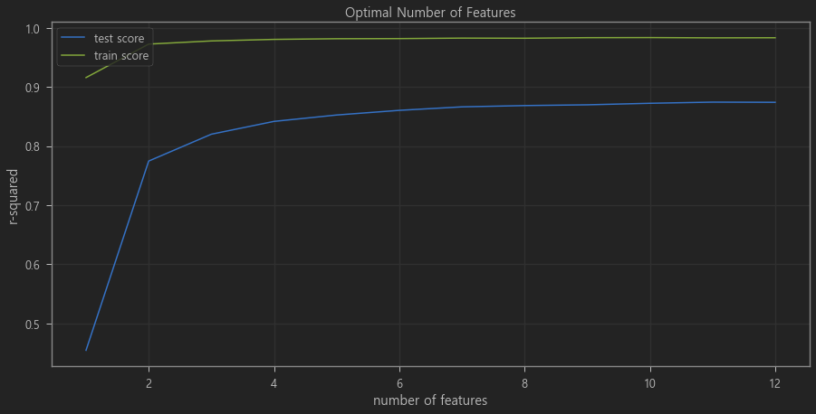

```python
# plotting cv results
plt.figure(figsize=(15,7))

plt.plot(cv_results["param_n_features_to_select"], cv_results["mean_test_score"])
plt.plot(cv_results["param_n_features_to_select"], cv_results["mean_train_score"])
plt.xlabel('number of features')
plt.ylabel('r-squared')
plt.title("Optimal Number of Features")
plt.legend(['test score', 'train score'], loc='upper left')
```

# 2. XGBoost

XGBoost 는 Ensemble boosting 방식으로 High bias 의 어려운 문제에 사용  
Hyperparameter tuning 과정이 필요하다

```python
import xgboost as xgb
from sklearn.metrics import mean_squared_error
from sklearn.metrics import mean_absolute_error
import pandas as pd
import numpy as np
from sklearn.model_selection import train_test_split

# input data
X = housing_df_o_n.drop(columns=["MEDV"])
y = housing_df_o_n["MEDV"] #target column

# split data
X_train, X_test, y_train, y_test = train_test_split(X, y, test_size=0.2, random_state=0)

# convert to DMatrix
dtrain = xgb.DMatrix(X_train, label=y_train)
dtest = xgb.DMatrix(X_test, label=y_test)
```

### Grid-search hyperparameter tuning

```python
# parameters
num_boost_round = 1000
params = {
    'max_depth':5,
    'min_child_weight': 8,
    'subsample': 0.9,
    'colsample_bytree': 0.9,
    'eta': 0.3,
    'objective':'reg:squarederror',
    'learning_rate' : 0.1,
    'eval_metric' : "mae"
}

model = xgb.train(
    params,
    dtrain,
    num_boost_round=num_boost_round,
    evals=[(dtest, "Test")],
    early_stopping_rounds=10
)

print("Best MAE: {:.2f} with {} rounds".format(model.best_score, model.best_iteration+1))
```

```
[0]	Test-mae:0.794209
Will train until Test-mae hasn't improved in 10 rounds.
[1]	Test-mae:0.720531
[2]	Test-mae:0.656319
[3]	Test-mae:0.600671
[4]	Test-mae:0.551341
[5]	Test-mae:0.507225
[6]	Test-mae:0.466046
[7]	Test-mae:0.430034
[8]	Test-mae:0.399056
[9]	Test-mae:0.371147
[10]	Test-mae:0.346102
[11]	Test-mae:0.325736
[12]	Test-mae:0.312604
[13]	Test-mae:0.299987
[14]	Test-mae:0.288807
[15]	Test-mae:0.281028
[16]	Test-mae:0.27563
[17]	Test-mae:0.269901
[18]	Test-mae:0.264994
[19]	Test-mae:0.260024
[20]	Test-mae:0.257766
[21]	Test-mae:0.25485
[22]	Test-mae:0.25371
[23]	Test-mae:0.252646
[24]	Test-mae:0.251459
[25]	Test-mae:0.250544
[26]	Test-mae:0.249684
[27]	Test-mae:0.249367
[28]	Test-mae:0.249184
[29]	Test-mae:0.247244
[30]	Test-mae:0.244737
[31]	Test-mae:0.242797
[32]	Test-mae:0.242468
[33]	Test-mae:0.241134
[34]	Test-mae:0.24113
[35]	Test-mae:0.240793
[36]	Test-mae:0.240686
[37]	Test-mae:0.240691
[38]	Test-mae:0.241406
[39]	Test-mae:0.241912
[40]	Test-mae:0.241971
[41]	Test-mae:0.241959
[42]	Test-mae:0.241662
[43]	Test-mae:0.241674
[44]	Test-mae:0.241991
[45]	Test-mae:0.242206
[46]	Test-mae:0.242892
Stopping. Best iteration:
[36]	Test-mae:0.240686

Best MAE: 0.24 with 37 rounds
```

```python
# grid_search - num_boost_round
# k-fold cross-validation
cv_results = xgb.cv(
    params,
    dtrain,
    num_boost_round=num_boost_round,
    seed=42,
    nfold=5,
    metrics={'mae'},
    early_stopping_rounds=10
)
print(cv_results['test-mae-mean'].idxmin(), cv_results['test-mae-mean'].min())
cv_results
```

```
137 0.21363279999999998
```

|  | train-mae-mean | train-mae-std | test-mae-mean | test-mae-std |
| --- | --- | --- | --- | --- |
| 0 | 0.854384 | 0.011695 | 0.859918 | 0.045154 |
| 1 | 0.780651 | 0.011195 | 0.788059 | 0.039829 |
| 2 | 0.713167 | 0.010681 | 0.723147 | 0.035286 |
| 3 | 0.653024 | 0.009631 | 0.667127 | 0.033951 |
| 4 | 0.598589 | 0.009106 | 0.615407 | 0.032688 |
| ... | ... | ... | ... | ... |
| 133 | 0.054917 | 0.001177 | 0.213873 | 0.020690 |
| 134 | 0.054567 | 0.001080 | 0.213805 | 0.020684 |
| 135 | 0.054127 | 0.001082 | 0.213713 | 0.021052 |
| 136 | 0.053741 | 0.001147 | 0.213648 | 0.020868 |
| 137 | 0.053540 | 0.001073 | 0.213633 | 0.020935 |

138 rows × 4 columns

```python
## grid_search - max_depth, min_child_weight
num_boost_round = 137
gridsearch_params = [
    (max_depth, min_child_weight)
    for max_depth in range(5,14)
    for min_child_weight in range(1,10)
]

# Define initial best params and MAE
min_mae = float("Inf")
best_params = None
for max_depth, min_child_weight in gridsearch_params:
#     print("CV with max_depth={}, min_child_weight={}".format(
#                              max_depth,
#                              min_child_weight))
    # Update our parameters
    params['max_depth'] = max_depth
    params['min_child_weight'] = min_child_weight
    # Run CV
    cv_results = xgb.cv(
        params,
        dtrain,
        num_boost_round=num_boost_round,
        seed=42,
        nfold=5,
        metrics={'mae'},
        early_stopping_rounds=10
    )
    # Update best MAE
    mean_mae = cv_results['test-mae-mean'].min()
    boost_rounds = cv_results['test-mae-mean'].argmin()
#     print("\tMAE {} for {} rounds".format(mean_mae, boost_rounds))
    if mean_mae < min_mae:
        min_mae = mean_mae
        best_params = (max_depth,min_child_weight)
print("Best params: {}, {}, MAE: {}".format(best_params[0], best_params[1], min_mae))
```

```
Best params: 5, 8, MAE: 0.2136478
```

```python
## grid_search - subsample, colsample
num_boost_round = 137
params['max_depth'] = 5
params['min_child_weight'] = 8

gridsearch_params = [
    (subsample, colsample)
    for subsample in [i/10. for i in range(5,11)]
    for colsample in [i/10. for i in range(5,11)]
]

min_mae = float("Inf")
best_params = None
# We start by the largest values and go down to the smallest
for subsample, colsample in reversed(gridsearch_params):
#     print("CV with subsample={}, colsample={}".format(
#                              subsample,
#                              colsample))
    # We update our parameters
    params['subsample'] = subsample
    params['colsample_bytree'] = colsample
    # Run CV
    cv_results = xgb.cv(
        params,
        dtrain,
        num_boost_round=num_boost_round,
        seed=42,
        nfold=5,
        metrics={'mae'},
        early_stopping_rounds=10
    )
    # Update best score
    mean_mae = cv_results['test-mae-mean'].min()
    boost_rounds = cv_results['test-mae-mean'].argmin()
#     print("\tMAE {} for {} rounds".format(mean_mae, boost_rounds))
    if mean_mae < min_mae:
        min_mae = mean_mae
        best_params = (subsample,colsample)
print("Best params: {}, {}, MAE: {}".format(best_params[0], best_params[1], min_mae))
```

```
Best params: 0.9, 0.9, MAE: 0.2136478
```

```python
## grid_search - ETA
num_boost_round = 137
params['max_depth'] = 5
params['min_child_weight'] = 8
params['subsample'] = .9
params['colsample_bytree'] = .9

min_mae = float("Inf")
best_params = None
for eta in [1.0, .5, .4, .3, .2, .1, .05, .01, .005]:
#     print("CV with eta={}".format(eta))
    # We update our parameters
    params['eta'] = eta
    # Run and time CV
    cv_results = xgb.cv(
            params,
            dtrain,
            num_boost_round=num_boost_round,
            seed=42,
            nfold=5,
            metrics=['mae'],
            early_stopping_rounds=10
          )
    # Update best score
    mean_mae = cv_results['test-mae-mean'].min()
    boost_rounds = cv_results['test-mae-mean'].argmin()
#     print("\tMAE {} for {} rounds\n".format(mean_mae, boost_rounds))
    if mean_mae < min_mae:
        min_mae = mean_mae
        best_params = eta
print("Best params: {}, MAE: {}".format(best_params, min_mae))
```

```
Best params: 1.0, MAE: 0.2136478
```

```python
# final hyperparameters
num_boost_round = 137
params= {
         'eval_metric': 'mae',
         'max_depth': 5,
         'min_child_weight': 8,
         'objective': 'reg:squarederror',
         'subsample': 0.9,
         'colsample_bytree': 0.9,
         'eta': 1.0,
        }
```

### Evaluation

```python
# Accuracy
xg_reg = xgb.XGBRegressor(**params, \
                          num_boost_round=num_boost_round, \
                          early_stopping_rounds=10)
xg_reg.fit(X_train,y_train)
preds = xg_reg.predict(X_test)

print("Training Accuracy:", xg_reg.score(X_train, y_train)*100)
print("Testing Accuracy:", xg_reg.score(X_test, y_test)*100)
print("R Squre:", r2_score(y, xg_reg.predict(X))*100)
print("Mean Absolute Error:", mean_absolute_error(xg_reg.predict(X), y))
```

```
Training Accuracy: 98.88264877386924
Testing Accuracy: 89.27153356322862
R Squre: 97.03003572611946
Mean Absolute Error: 0.10931981510858571
```

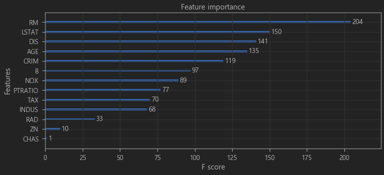

```python
# Feature importance
xgb.plot_importance(xg_reg, importance_type="weight")
plt.rcParams['figure.figsize'] = [11, 8]
plt.show()
```

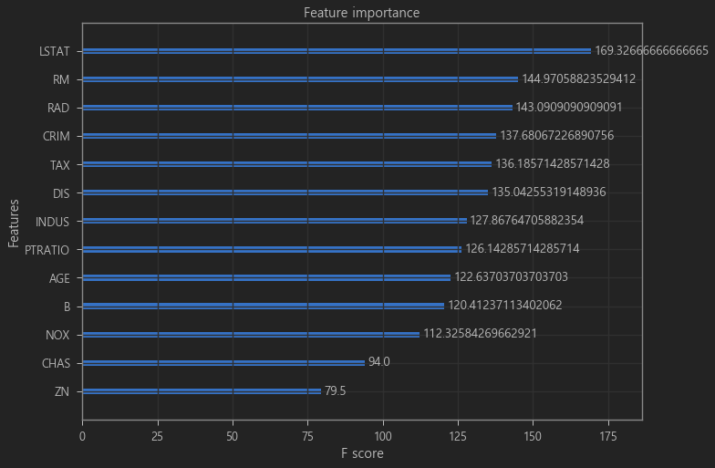

```python
# Feature importance
xgb.plot_importance(xg_reg, importance_type="cover")
plt.rcParams['figure.figsize'] = [11, 8]
plt.show()
```

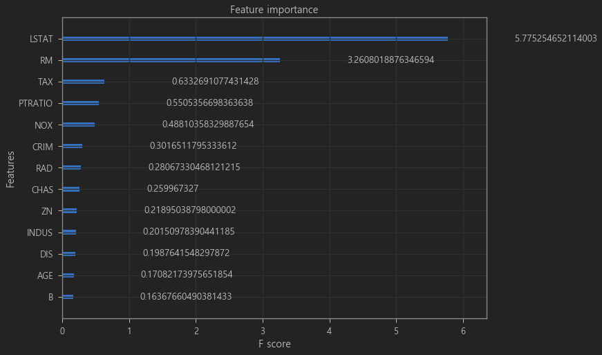

```python
# Feature importance
xgb.plot_importance(xg_reg, importance_type="gain")
plt.rcParams['figure.figsize'] = [11, 8]
plt.show()
```

weight(가중치), cover(적용범위), gain(Gini) 에 따라서 feature importance 순위 변화  
LSTAT (저소득자비율) 과 RM (평균방수) 는 모든 방법에서 상위 랭크

# 모형, 변수 해석

SHAP (SHapley Additive exPlanations)  
https://proceedings.neurips.cc/paper/2017/hash/8a20a8621978632d76c43dfd28b67767-Abstract.html  
변수 기여도 해석을 위해 일관성과 정확성을 확보한 방법

```python
import shap

# explain the model's predictions using SHAP
explainer = shap.TreeExplainer(xg_reg)
shap_values = explainer.shap_values(X)
```

#### SHAP 방식으로 계산해보면 LSTAT, RM 이 큰 차이로 중요한 2개의 변수로 나타난다.

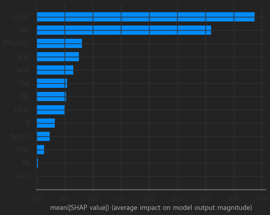

```python
shap.summary_plot(shap_values, X, plot_type="bar")
```

#### 방수가 많을수록 집값이 비싸고, 저소득층비율이 높을 수록 싸다.

- RM 은 표준화값 기준 0이하에서는 집값에 영향이 적다

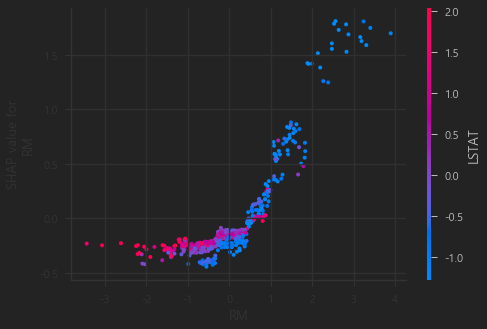

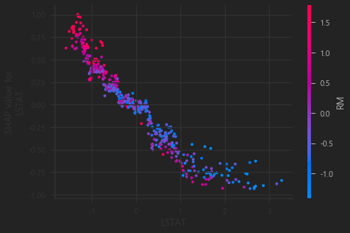

```python
# create a dependence plot to show the effect of a single feature across the whole dataset
shap.dependence_plot("RM", shap_values, X)

# create a dependence plot to show the effect of a single feature across the whole dataset
shap.dependence_plot("LSTAT", shap_values, X)
```

#### 아래 그래프의 빨간색의 방향이 집값에 영향을 주는 방향

- LSTAT, PTRATIO, AGE, NOX, TAX, DIS, CRIM 은 부정적 영향
- RM 은 매우 긍정적, B ,INDUS 은 다소 긍정적 영향

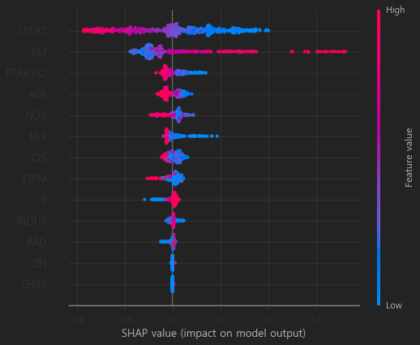

```python
shap.summary_plot(shap_values, X)
```

```python
# visualize the first prediction's explanation (use matplotlib=True to avoid Javascript)
shap.initjs()
shap.force_plot(explainer.expected_value, shap_values[0,:], X.iloc[0,:])
```

```python
# visualize the training set predictions
shap.initjs()
shap.force_plot(explainer.expected_value, shap_values, X)
```